# Point Pattern Analysis

Vitoria Barbosa Ferreira

5/13/2021

## Introduction

This assigment focuses on a point pattern analysis using natural and simulated individual tree locations, situated at the alpine tree line in the Passeier valley (South Tyrol, in North Italy).This dataset is part of Gudrun Wallentin’s thesis about individual tree modelling.

## Nearest Neighbour Point Analysis

In order to compare real-word trees distribution with simulated tree distribution, we will perform a Nearest Neighbor point Analysis, aiming to calculate the distance between individual trees and its nearest neighbor.

Since we want to compare both datasets we will use the mean nearest neighbor. The output shows that the mean distance between the real-world trees is around 6.70m. Simulated trees shows a very simular result, around 6.67m. The nearest neighbor index, which indicates how clustered is the data, shows that the real-word trees tend to be more clustered (nn index less than 1) than the simulated trees (nn index more than 1).

However, the p-value, or the probability of the observed spatial pattern was created by some random process (ESRI), of both datasets shows that it is very unlike to be completely randomly distributed, which is also proved by the high and very low z-score values.

Real-world Trees

| d.NNI | d.z.score | d.p | d.expected.mean.distance | d.observed.mean.distance |
| --- | --- | --- | --- | --- |
| 0.9654683 | -4.253158 | 2.11e-05 | 6.947764 | 6.707846 |

Simulated Trees

| s.NNI | s.z.score | s.p | s.expected.mean.distance | s.observed.mean.distance |
| --- | --- | --- | --- | --- |
| 1.065133 | 7.76052 | 0 | 6.270697 | 6.679125 |

Now that we know that data is not completely random distributed, lets further analyze the simulated trees dataset. For that we will split the data based on its main attribute, the height. Two subgroups were defined based on the median value, which is about 11.88m. The histogram below shows the distribution of the simulated trees’height.

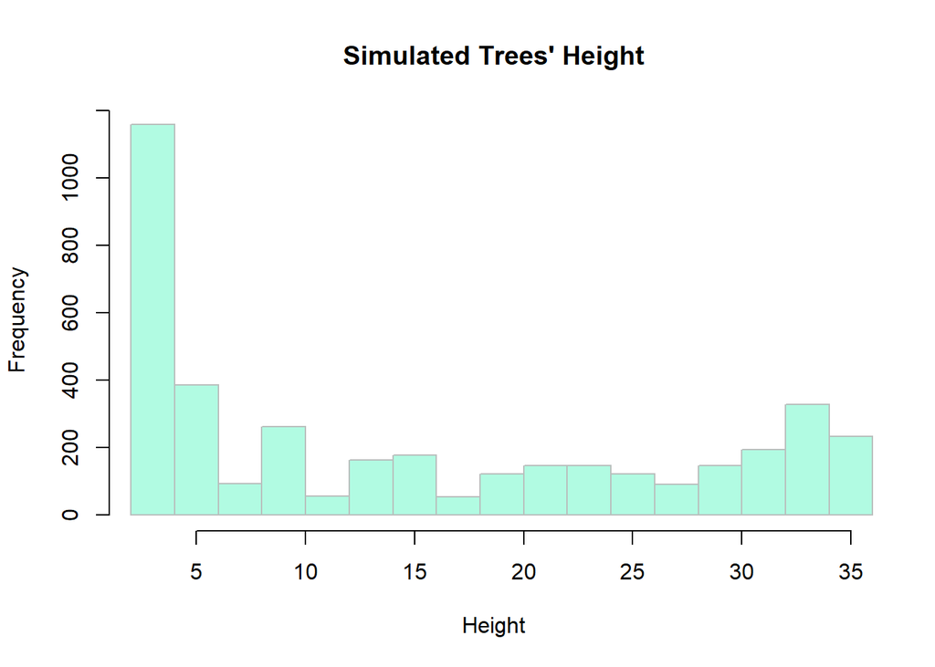

Simulated Trees - Trees’Height < 11.88

| s.NNI | s.z.score | s.p | s.expected.mean.distance | s.observed.mean.distance |
| --- | --- | --- | --- | --- |
| 0.8000159 | -16.84671 | 0 | 8.824089 | 7.059412 |

Simulated Trees - Trees’Height > 11.88m

| s.NNI | s.z.score | s.p | s.expected.mean.distance | s.observed.mean.distance |
| --- | --- | --- | --- | --- |
| 1.10117 | 8.522558 | 0 | 7.612068 | 8.382178 |

In the sequence, we decided to further split the simulated data with trees’height less than 11.88m into clustered, dispersed and random by visual inspection of the following plot.

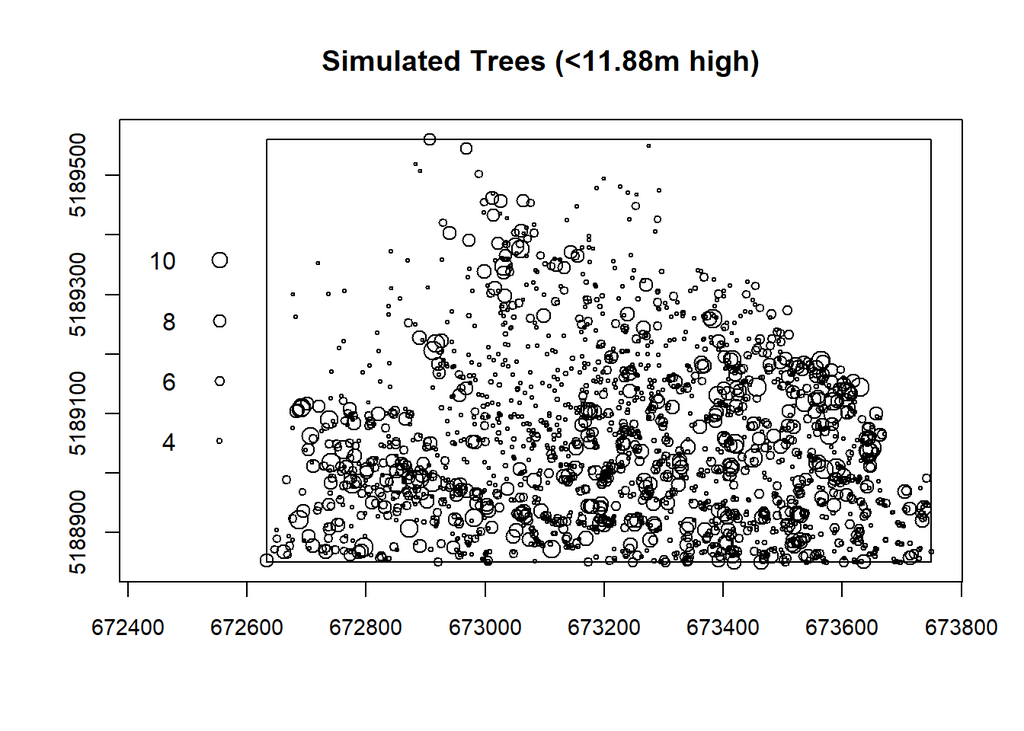

Clustered

| c.NNI | c.z.score | c.p | c.expected.mean.distance | c.observed.mean.distance |
| --- | --- | --- | --- | --- |
| 0.815331 | -10.72148 | 0 | 7.009955 | 5.715434 |

Dispersed

| d.NNI | d.z.score | d.p | d.expected.mean.distance | d.observed.mean.distance |
| --- | --- | --- | --- | --- |
| 0.869654 | -7.460024 | 0 | 8.492633 | 7.385652 |

Random

| r.NNI | r.z.score | r.p | r.expected.mean.distance | r.observed.mean.distance |
| --- | --- | --- | --- | --- |
| 0.919903 | -1.699416 | 0.0892408 | 17.33828 | 15.94954 |

## Ripley‘s K-function

Lastly, we will use the Ripley’s k-function to analyze the degree of clustering of the subgroups: clustered, dispersed and random. Instead of measuring the nearest distance between the points, the Ripley‘s K-function method considers all the distances between events in the study area.In the plots below, the dashed line represents the expected value under complete spatial randomness (CSR) and the black solid line indicates the actual estimated values. In all cases, since the estimated values varies significantly frpm CSR, it indicates the tendency of clustering, emphasizing the previous outputs.

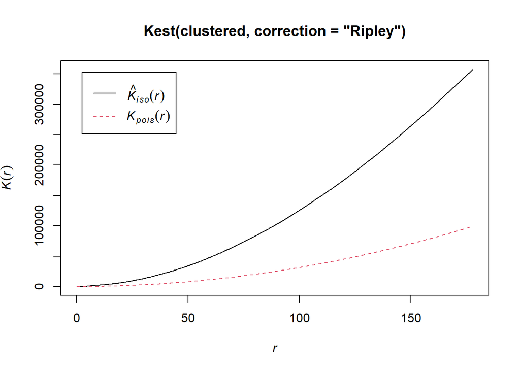

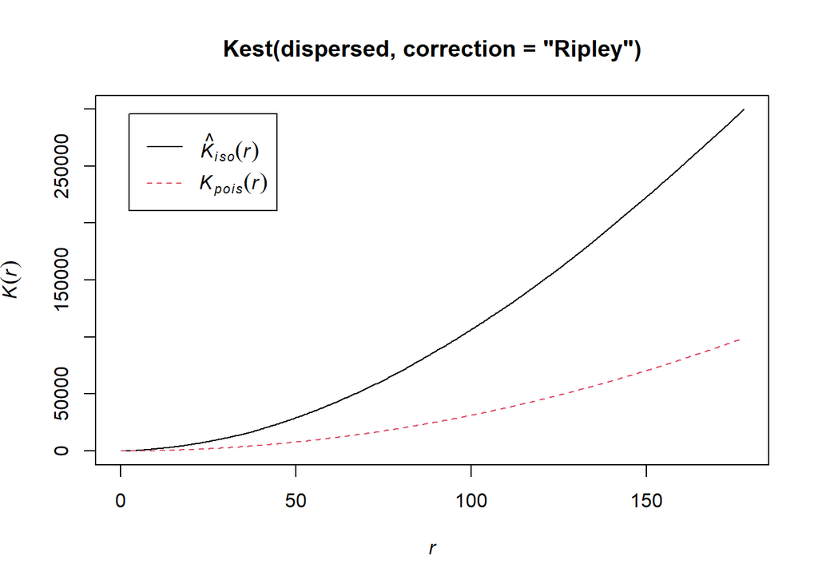

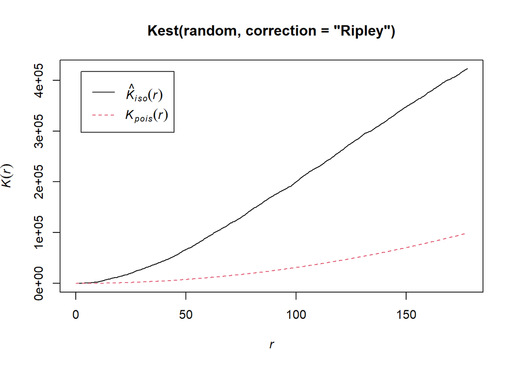